# Separate Admixture analysis

## All Alpine lakes

#### Removing species with less than 10 individuals/samples

```r
poptable <- read.table('~/cophyhopa/data/popmap.txt',
                       col.names = c('sample', 'group', 'pop', 'lake'))

poptable <- poptable[-which(poptable[,3] == "C.alpinus"), ]
poptable <- poptable[-which(poptable[,3] == "C.alpinus/C.steinmanni"), ]
poptable <- poptable[-which(poptable[,3] == "C.brienzii"), ]
poptable <- poptable[-which(poptable[,3] == "C.fatioi/C.albellus"), ]
poptable <- poptable[-which(poptable[,3] == "D"), ]
poptable <- poptable[-which(poptable[,3] == "L"), ]
poptable <- poptable[-which(poptable[,3] == "P"), ]
poptable <- poptable[-which(poptable[,3] == "C.brienzii/C.fatioi"), ]

write.table(poptable[,1], file = '~/cophyhopa/results/2022-05-09/admixture/ALP.txt', quote = FALSE,
            row.names = FALSE, col.names = FALSE)
```

#### Data selecting and filtering

```bash
VCF='/gata/mar/cophyhopa/results/2022-04-22/assem2_outfiles/assem2.vcf'
FILE=ALP
if [ ! -e $FILE.vcf.gz ]; then
   vcftools --vcf $VCF \
            --out dirty \
            --keep ALP.txt \
            --remove ~/cophyhopa/results/2022-05-04/TheWorst.txt \
            --recode \
            --recode-INFO-all
   vcftools --vcf dirty.recode.vcf \
            --out $FILE \
            --thin 500 \
            --remove-indels \
            --mac 2 \
            --max-alleles 2 \
            --max-meanDP 1000 \
            --max-missing-count 7 \
            --stdout \
            --recode --recode-INFO-all \
            | gzip > $FILE.vcf.gz
fi
if [ -e dirty.recode.vcf ]; then rm dirty.recode.vcf; fi

if [ ! -e chromMap.txt ]; then
   gunzip -c $FILE".vcf.gz" | \
   gawk '(/^[^#]/){
      A[$1] = 1
   }END{
      N = 1
      for (chr in A) {
         print chr "\t" N
         N = N + 1
      }
   }' > chromMap.txt
fi

vcftools --gzvcf $FILE".vcf.gz" \
         --plink --mac 2 --remove-indels --max-alleles 2 \
         --chrom-map chromMap.txt \
         --out $FILE

gawk -v OFS="\t" '{
   $1 = 1
   $2 = 1 ":" $4
   print $0
}' $FILE".map" > better.map
mv better.map $FILE.map

plink --file $FILE --make-bed --out $FILE --allow-no-sex --allow-extra-chr 0
```

#### Admixture analysis with variant K

We define the K parameter from 7 to 10, computing the cross-validation error. Then, we extract these values.

```bash
INPUT='/gata/mar/cophyhopa/results/2022-05-09/admixture/ALP.bed'

for K in 7 8 9 10; do
  if [ ! -e log${K}.ALP.out ]; then
    admixture --cv $INPUT $K | tee log${K}.ALP.out;
  fi
done
```

```bash
grep -h CV log*.ALP.out
```

```
## CV error (K=10): 0.40873
## CV error (K=7): 0.36292
## CV error (K=8): 0.37301
## CV error (K=9): 0.39715
```

#### Plot Q estimates for K = 7, 8, 9 and 10

We choose the K that has given a lower value of the cross-validation error. We add the sample names and display a barplot

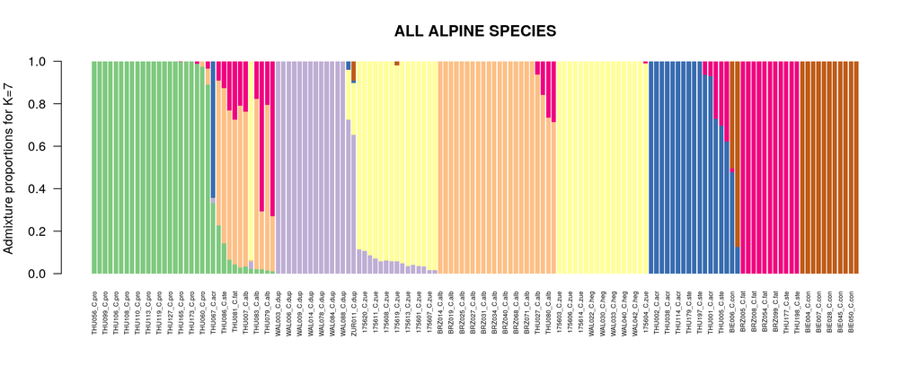

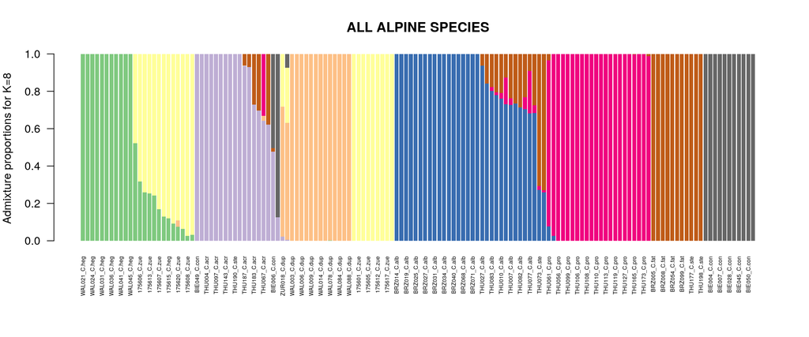

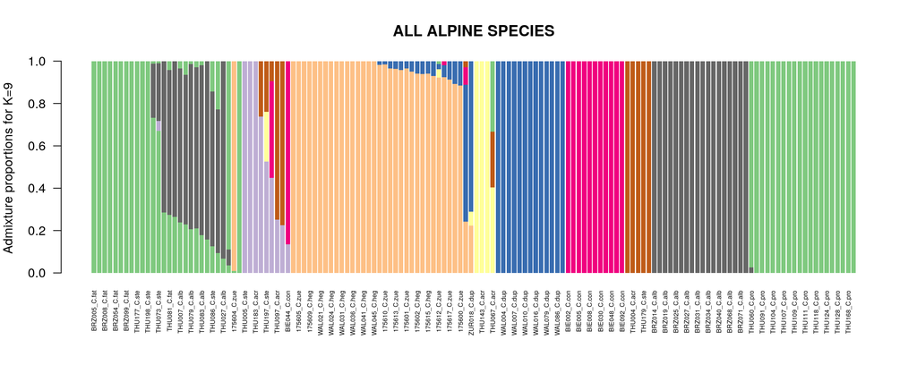

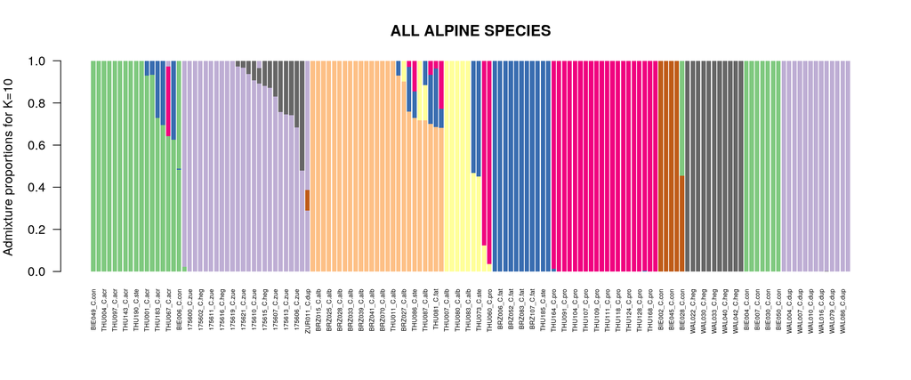

# Species in Arctic lakes

## Lakes Suohpatjavri and Langfjordvatn

#### Data selecting and filtering

```bash
VCF='/gata/mar/cophyhopa/results/2022-04-22/assem2_outfiles/assem2.vcf'
FILE=ARC
if [ ! -e $FILE.vcf.gz ]; then
   vcftools --vcf $VCF \
            --out dirty \
            --keep ~/cophyhopa/data/Arctic.txt \
            --remove ~/cophyhopa/results/2022-05-04/TheWorst.txt \
            --recode \
            --recode-INFO-all
   vcftools --vcf dirty.recode.vcf \
            --out $FILE \
            --thin 500 \
            --remove-indels \
            --mac 2 \
            --max-alleles 2 \
            --max-meanDP 1000 \
            --max-missing-count 7 \
            --stdout \
            --recode --recode-INFO-all \
            | gzip > $FILE.vcf.gz
fi
if [ -e dirty.recode.vcf ]; then rm dirty.recode.vcf; fi

if [ ! -e chromMap.txt ]; then
   gunzip -c $FILE".vcf.gz" | \
   gawk '(/^[^#]/){
      A[$1] = 1
   }END{
      N = 1
      for (chr in A) {
         print chr "\t" N
         N = N + 1
      }
   }' > chromMap.txt
fi

vcftools --gzvcf $FILE".vcf.gz" \
         --plink --mac 2 --remove-indels --max-alleles 2 \
         --chrom-map chromMap.txt \
         --out $FILE

gawk -v OFS="\t" '{
   $1 = 1
   $2 = 1 ":" $4
   print $0
}' $FILE".map" > better.map
mv better.map $FILE.map

plink --file $FILE --make-bed --out $FILE --allow-no-sex --allow-extra-chr 0
```

#### Admixture analysis with variant K

We define the K parameter from 2 to 4, computing the cross-validation error. Then, we extract these values.

```bash
INPUT='/gata/mar/cophyhopa/results/2022-05-09/admixture/ARC.bed'

for K in 2 3 4; do
  if [ ! -e log${K}.ARC.out ]; then
    admixture --cv $INPUT $K | tee log${K}.ARC.out;
  fi
done
```

```bash
grep -h CV log*.ARC.out
```

```
## CV error (K=2): 0.36466
## CV error (K=3): 0.37365
## CV error (K=4): 0.36559
```

We choose the K that has given a lower value of the cross-validation error. We add the sample names and display a barplot.

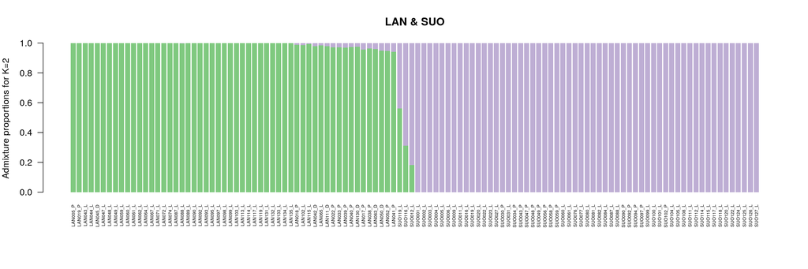

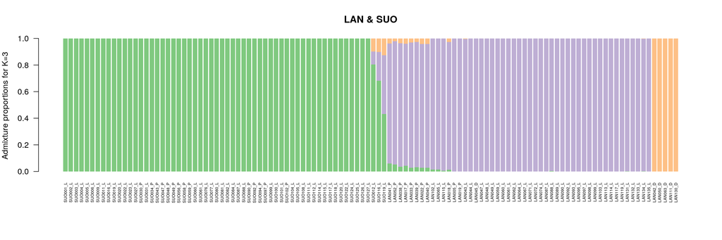

[figure not shown]